# Introduction to Pandas

## Installation

Simply,

```
pip install pandas
```

## Reading data from a CSV file

You can read data from a CSV file using the `read_csv` function. By default, it assumes that the fields are comma-separated.

```python
# import pandas
import pandas as pd
import matplotlib.pyplot as plt
import numpy as np
```

> The `imdb.csv` dataset contains Highest Rated IMDb "Top 1000" Titles.

```python
# load imdb dataset as pandas dataframe
df = pd.read_csv('imdb_1000.csv')
df
```

|  | star_rating | title | content_rating | genre | duration | actors_list |
| --- | --- | --- | --- | --- | --- | --- |
| 0 | 9.3 | The Shawshank Redemption | R | Crime | 142 | [u'Tim Robbins', u'Morgan Freeman', u'Bob Gunt... |
| 1 | 9.2 | The Godfather | R | Crime | 175 | [u'Marlon Brando', u'Al Pacino', u'James Caan'] |
| 2 | 9.1 | The Godfather: Part II | R | Crime | 200 | [u'Al Pacino', u'Robert De Niro', u'Robert Duv... |
| 3 | 9.0 | The Dark Knight | PG-13 | Action | 152 | [u'Christian Bale', u'Heath Ledger', u'Aaron E... |
| 4 | 8.9 | Pulp Fiction | R | Crime | 154 | [u'John Travolta', u'Uma Thurman', u'Samuel L.... |
| ... | ... | ... | ... | ... | ... | ... |
| 974 | 7.4 | Tootsie | PG | Comedy | 116 | [u'Dustin Hoffman', u'Jessica Lange', u'Teri G... |
| 975 | 7.4 | Back to the Future Part III | PG | Adventure | 118 | [u'Michael J. Fox', u'Christopher Lloyd', u'Ma... |
| 976 | 7.4 | Master and Commander: The Far Side of the World | PG-13 | Action | 138 | [u'Russell Crowe', u'Paul Bettany', u'Billy Bo... |
| 977 | 7.4 | Poltergeist | PG | Horror | 114 | [u'JoBeth Williams', u"Heather O'Rourke", u'Cr... |
| 978 | 7.4 | Wall Street | R | Crime | 126 | [u'Charlie Sheen', u'Michael Douglas', u'Tamar... |

979 rows × 6 columns

```python
# show first 5 rows of imdb_df
df.head(5)
```

|  | star_rating | title | content_rating | genre | duration | actors_list |
| --- | --- | --- | --- | --- | --- | --- |
| 0 | 9.3 | The Shawshank Redemption | R | Crime | 142 | [u'Tim Robbins', u'Morgan Freeman', u'Bob Gunt... |
| 1 | 9.2 | The Godfather | R | Crime | 175 | [u'Marlon Brando', u'Al Pacino', u'James Caan'] |
| 2 | 9.1 | The Godfather: Part II | R | Crime | 200 | [u'Al Pacino', u'Robert De Niro', u'Robert Duv... |
| 3 | 9.0 | The Dark Knight | PG-13 | Action | 152 | [u'Christian Bale', u'Heath Ledger', u'Aaron E... |
| 4 | 8.9 | Pulp Fiction | R | Crime | 154 | [u'John Travolta', u'Uma Thurman', u'Samuel L.... |

> The `bikes.csv` dataset contains information about the number of bicycles that used certain bicycle lanes in Montreal in the year 2012.

```python
# load bikes dataset as pandas dataframe
df2 = pd.read_csv('bikes.csv',sep=';',encoding='latin1',parse_dates=['Date'], dayfirst=True)
df2
```

|  | Date | Unnamed: 1 | Rachel / Papineau | Berri1 | Maisonneuve_2 | Maisonneuve_1 | Brébeuf | Parc | PierDup | CSC (Côte Sainte-Catherine) | Pont_Jacques_Cartier |
| --- | --- | --- | --- | --- | --- | --- | --- | --- | --- | --- | --- |
| 0 | 2012-01-01 | 00:00 | 16 | 35 | 51 | 38 | 5.0 | 26 | 10 | 0 | 27.0 |
| 1 | 2012-01-02 | 00:00 | 43 | 83 | 153 | 68 | 11.0 | 53 | 6 | 1 | 21.0 |
| 2 | 2012-01-03 | 00:00 | 58 | 135 | 248 | 104 | 2.0 | 89 | 3 | 2 | 15.0 |
| 3 | 2012-01-04 | 00:00 | 61 | 144 | 318 | 116 | 2.0 | 111 | 8 | 1 | 19.0 |
| 4 | 2012-01-05 | 00:00 | 95 | 197 | 330 | 124 | 6.0 | 97 | 13 | 2 | 16.0 |
| ... | ... | ... | ... | ... | ... | ... | ... | ... | ... | ... | ... |
| 361 | 2012-12-27 | 00:00 | 8 | 12 | 7 | 4 | NaN | 1 | 2 | 0 | NaN |
| 362 | 2012-12-28 | 00:00 | 0 | 35 | 3 | 38 | NaN | 0 | 0 | 0 | NaN |
| 363 | 2012-12-29 | 00:00 | 0 | 27 | 8 | 42 | NaN | 9 | 0 | 0 | NaN |
| 364 | 2012-12-30 | 00:00 | 0 | 5 | 1 | 5 | NaN | 6 | 0 | 0 | NaN |
| 365 | 2012-12-31 | 00:00 | 0 | 4 | 3 | 8 | NaN | 12 | 0 | 0 | NaN |

366 rows × 11 columns

```python
# show first 3 rows of bikes_df
df2.head(3)
```

[output not shown]

## Selecting columns

When you read a CSV, you get a kind of object called a DataFrame, which is made up of rows and columns. You get columns out of a DataFrame the same way you get elements out of a dictionary.

```python
# list columns of imdb_df
print(df.columns)
```

```
Index(['star_rating', 'title', 'content_rating', 'genre', 'duration',
       'actors_list'],
      dtype='object')
```

```python
# what are the datatypes of values in columns
df.dtypes
```

```
star_rating       float64
title              object
content_rating     object
genre              object
duration            int64
actors_list        object
dtype: object
```

```python
# list first 5 movie titles
df[['title']].head(5)
```

|  | title |
| --- | --- |
| 0 | The Shawshank Redemption |
| 1 | The Godfather |
| 2 | The Godfather: Part II |
| 3 | The Dark Knight |
| 4 | Pulp Fiction |

```python
# show only movie title and genre
df[['title', 'genre']]
```

|  | title | genre |
| --- | --- | --- |
| 0 | The Shawshank Redemption | Crime |
| 1 | The Godfather | Crime |
| 2 | The Godfather: Part II | Crime |
| 3 | The Dark Knight | Action |
| 4 | Pulp Fiction | Crime |
| ... | ... | ... |
| 974 | Tootsie | Comedy |
| 975 | Back to the Future Part III | Adventure |
| 976 | Master and Commander: The Far Side of the World | Action |
| 977 | Poltergeist | Horror |
| 978 | Wall Street | Crime |

979 rows × 2 columns

## Understanding columns

On the inside, the type of a column is `pd.Series` and pandas Series are internally numpy arrays. If you add `.values` to the end of any Series, you'll get its internal **numpy array**.

```python
# show the type of duration column
print(type(df['duration']))
```

```
<class 'pandas.core.series.Series'>
```

```python
# show duration values of movies as numpy arrays
d=df[['duration']].to_numpy()
d
```

[output not shown]

[output cut: 924 more lines]

[output not shown]

## Applying functions to columns

Use `.apply` function to apply any function to each element of a column.

```python
# convert all the movie titles to uppercase
df['title']=df['title'].str.upper()
df['title']
```

```
0                             THE SHAWSHANK REDEMPTION
1                                        THE GODFATHER
2                               THE GODFATHER: PART II
3                                      THE DARK KNIGHT
4                                         PULP FICTION
                            ...
974                                            TOOTSIE
975                        BACK TO THE FUTURE PART III
976    MASTER AND COMMANDER: THE FAR SIDE OF THE WORLD
977                                        POLTERGEIST
978                                        WALL STREET
Name: title, Length: 979, dtype: object
```

## Plotting a column

Use `.plot()` function!

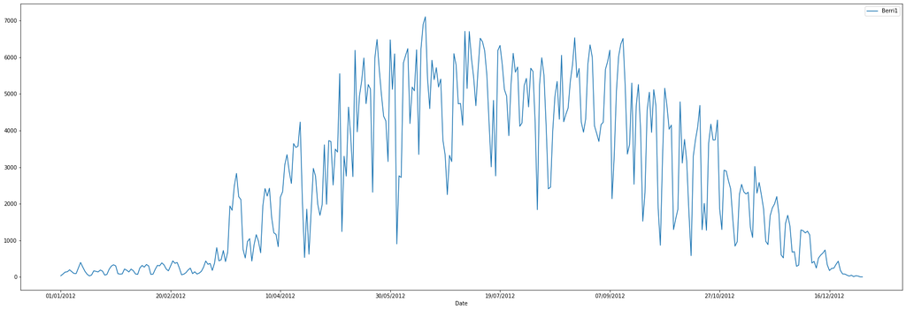

```python
# plot the bikers travelling to Berri1 over the year
import matplotlib.pyplot as plt

df2.plot(x='Date',y='Berri1',kind='line',figsize=(30,10))
plt.show()
```

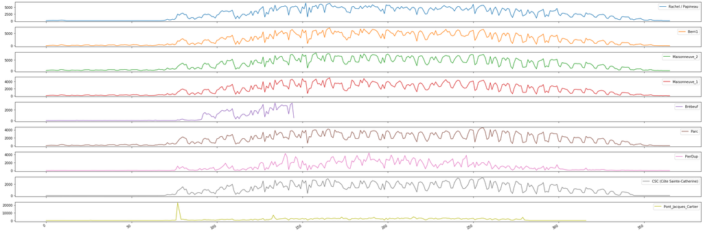

```python
# plot all the columns of bikes_df
df2.plot(subplots=True,figsize=(30,10))

plt.tight_layout()
plt.show()
```

## Value counts

Get count of unique values in a particular column/Series.

```python
# what are the unique genre in imdb_df?
#s = pd.value_counts(df.genre)
#s1 = pd.Series({'nunique': len(s), 'unique values': s.index.tolist()})
#s.append(s1)
print(df.genre.unique())
u = df.genre.nunique()
u
```

```
['Crime' 'Action' 'Drama' 'Western' 'Adventure' 'Biography' 'Comedy'
 'Animation' 'Mystery' 'Horror' 'Film-Noir' 'Sci-Fi' 'History' 'Thriller'
 'Family' 'Fantasy']
```

```
16
```

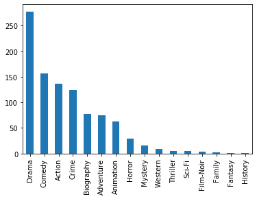

```python
# plotting value counts of unique genres as a bar chart
df['genre'].value_counts().plot(kind='bar')
```

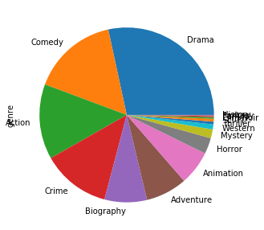

```python
# plotting value counts of unique genres as a pie chart
df['genre'].value_counts().plot(kind='pie',figsize=(10,5))
```

## Index

### DATAFRAME = COLUMNS + INDEX + ND DATA

### SERIES = INDEX + 1-D DATA

**Index** or (**row labels**) is one of the fundamental data structure of pandas. It can be thought of as an **immutable array** and an **ordered set**.

> Every row is uniquely identified by its index value.

```python
# show index of bikes_df
df2.index
```

```
RangeIndex(start=0, stop=366, step=1)
```

```python
# get row for date 2012-01-01
df2[df2['Date']=="2012-01-01"]
```

[output not shown]

#### To get row by integer index:

Use `.iloc[]` for purely integer-location based indexing for selection by position.

```python
# show 11th row of imdb_df using iloc
df2.iloc[11]
```

[output not shown]

## Selecting rows where column has a particular value

```python
# select only those movies where genre is adventure
df.loc[df['genre'] == 'Adventure']['title']
```

[output not shown]

```python
# which genre has highest number of movies with star rating above 8 and duration more than 130 minutes?
df[(df['star_rating']>8) & (df['duration']>130)]['genre']
```

```
0          Crime
1          Crime
2          Crime
3         Action
4          Crime
         ...
273    Biography
288        Drama
289        Drama
290        Crime
296       Action
Name: genre, Length: 115, dtype: object
```

## Adding a new column to DataFrame

```python
# add a weekday column to bikes_df
df2['weekday']=df2['Date'].dt.day_name()
df2
```

|  | Date | Unnamed: 1 | Rachel / Papineau | Berri1 | Maisonneuve_2 | Maisonneuve_1 | Brébeuf | Parc | PierDup | CSC (Côte Sainte-Catherine) | Pont_Jacques_Cartier | weekday |
| --- | --- | --- | --- | --- | --- | --- | --- | --- | --- | --- | --- | --- |
| 0 | 2012-01-01 | 00:00 | 16 | 35 | 51 | 38 | 5.0 | 26 | 10 | 0 | 27.0 | Sunday |
| 1 | 2012-01-02 | 00:00 | 43 | 83 | 153 | 68 | 11.0 | 53 | 6 | 1 | 21.0 | Monday |
| 2 | 2012-01-03 | 00:00 | 58 | 135 | 248 | 104 | 2.0 | 89 | 3 | 2 | 15.0 | Tuesday |
| 3 | 2012-01-04 | 00:00 | 61 | 144 | 318 | 116 | 2.0 | 111 | 8 | 1 | 19.0 | Wednesday |
| 4 | 2012-01-05 | 00:00 | 95 | 197 | 330 | 124 | 6.0 | 97 | 13 | 2 | 16.0 | Thursday |
| ... | ... | ... | ... | ... | ... | ... | ... | ... | ... | ... | ... | ... |
| 361 | 2012-12-27 | 00:00 | 8 | 12 | 7 | 4 | NaN | 1 | 2 | 0 | NaN | Thursday |
| 362 | 2012-12-28 | 00:00 | 0 | 35 | 3 | 38 | NaN | 0 | 0 | 0 | NaN | Friday |
| 363 | 2012-12-29 | 00:00 | 0 | 27 | 8 | 42 | NaN | 9 | 0 | 0 | NaN | Saturday |
| 364 | 2012-12-30 | 00:00 | 0 | 5 | 1 | 5 | NaN | 6 | 0 | 0 | NaN | Sunday |
| 365 | 2012-12-31 | 00:00 | 0 | 4 | 3 | 8 | NaN | 12 | 0 | 0 | NaN | Monday |

366 rows × 12 columns

## Deleting an existing column from DataFrame

```python
# remove column 'Unnamed: 1' from bikes_df
z=df2.drop('Unnamed: 1',axis=1)
z
```

[output not shown]

## Deleting a row in DataFrame

```python
# remove row no. 1 from bikes_df
z.drop([1],axis=0)
```

[output not shown]

## Group By

Any groupby operation involves one of the following operations on the original object. They are −

- Splitting the Object
- Applying a function
- Combining the results

In many situations, we split the data into sets and we apply some functionality on each subset. In the apply functionality, we can perform the following operations −

- **Aggregation** − computing a summary statistic
- **Transformation** − perform some group-specific operation
- **Filtration** − discarding the data with some condition

```python
# group imdb_df by movie genres
#print(df.groupby('genre').groups)
by_genres=df.groupby('genre')
by_genres
```

```
<pandas.core.groupby.generic.DataFrameGroupBy object at 0x0000019A95072408>
```

```python
# get crime movies group
cr = df.groupby('genre')
print(cr.get_group('Crime'))
```

```
     star_rating                     title content_rating  genre  duration  \
0            9.3  THE SHAWSHANK REDEMPTION              R  Crime       142
1            9.2             THE GODFATHER              R  Crime       175
2            9.1    THE GODFATHER: PART II              R  Crime       200
4            8.9              PULP FICTION              R  Crime       154
21           8.7               CITY OF GOD              R  Crime       130
..           ...                       ...            ...    ...       ...
927          7.5                     BRICK              R  Crime       110
931          7.4              MEAN STREETS              R  Crime       112
950          7.4                     BOUND              R  Crime       108
969          7.4       LAW ABIDING CITIZEN              R  Crime       109
978          7.4               WALL STREET              R  Crime       126

                                           actors_list
0    [u'Tim Robbins', u'Morgan Freeman', u'Bob Gunt...
1      [u'Marlon Brando', u'Al Pacino', u'James Caan']
2    [u'Al Pacino', u'Robert De Niro', u'Robert Duv...
4    [u'John Travolta', u'Uma Thurman', u'Samuel L....
21   [u'Alexandre Rodrigues', u'Matheus Nachtergael...
..                                                 ...
927  [u'Joseph Gordon-Levitt', u'Lukas Haas', u'Emi...
931  [u'Robert De Niro', u'Harvey Keitel', u'David ...
950  [u'Jennifer Tilly', u'Gina Gershon', u'Joe Pan...
969  [u'Gerard Butler', u'Jamie Foxx', u'Leslie Bibb']
978  [u'Charlie Sheen', u'Michael Douglas', u'Tamar...

[124 rows x 6 columns]
```

```python
# get mean of movie durations for each group
print(cr['duration'].agg(np.mean))
```

```
genre
Action       126.485294
Adventure    134.840000
Animation     96.596774
Biography    131.844156
Comedy       107.602564
Crime        122.298387
Drama        126.539568
Family       107.500000
Fantasy      112.000000
Film-Noir     97.333333
History       66.000000
Horror       102.517241
Mystery      115.625000
Sci-Fi       109.000000
Thriller     114.200000
Western      136.666667
Name: duration, dtype: float64
```

```python
# change duration of all movies in a particular genre to mean duration of the group
crime=df.groupby('genre').get_group('Crime')
crime['duration']=crime['duration'].mean()
crime[['title','duration']]
```

|  | title | duration |
| --- | --- | --- |
| 0 | THE SHAWSHANK REDEMPTION | 122.298387 |
| 1 | THE GODFATHER | 122.298387 |
| 2 | THE GODFATHER: PART II | 122.298387 |
| 4 | PULP FICTION | 122.298387 |
| 21 | CITY OF GOD | 122.298387 |
| ... | ... | ... |
| 927 | BRICK | 122.298387 |
| 931 | MEAN STREETS | 122.298387 |
| 950 | BOUND | 122.298387 |
| 969 | LAW ABIDING CITIZEN | 122.298387 |
| 978 | WALL STREET | 122.298387 |

124 rows × 2 columns

```python
# drop groups/genres that do not have average movie duration greater than 120.
y=df.drop(df[df.duration<120].index,inplace=True)
print(y)
df
```

```
None
```

[output not shown]

454 rows × 6 columns

```python
# group weekday wise bikers count
coun=df2.groupby('weekday').sum()
```

```python
# get weekday wise biker count
coun
```

| weekday | Rachel / Papineau | Berri1 | Maisonneuve_2 | Maisonneuve_1 | Brébeuf | Parc | PierDup | CSC (Côte Sainte-Catherine) | Pont_Jacques_Cartier |
| --- | --- | --- | --- | --- | --- | --- | --- | --- | --- |
| Friday | 146979 | 150493 | 183961 | 104584 | 12259.0 | 96569 | 43217 | 59856 | 62164.0 |
| Monday | 138881 | 142285 | 174610 | 95565 | 15436.0 | 97001 | 47259 | 64011 | 74692.0 |
| Saturday | 118560 | 105635 | 109902 | 64872 | 11170.0 | 51019 | 53360 | 35507 | 54493.0 |
| Sunday | 122115 | 102447 | 102272 | 57438 | 12032.0 | 52419 | 62070 | 37867 | 84638.0 |
| Thursday | 150971 | 169976 | 210039 | 118633 | 15679.0 | 113675 | 46117 | 73215 | 62174.0 |
| Tuesday | 131632 | 145795 | 179939 | 99421 | 10629.0 | 100007 | 35901 | 63503 | 53552.0 |
| Wednesday | 144531 | 163603 | 200273 | 112344 | 14876.0 | 110820 | 44045 | 72047 | 63472.0 |

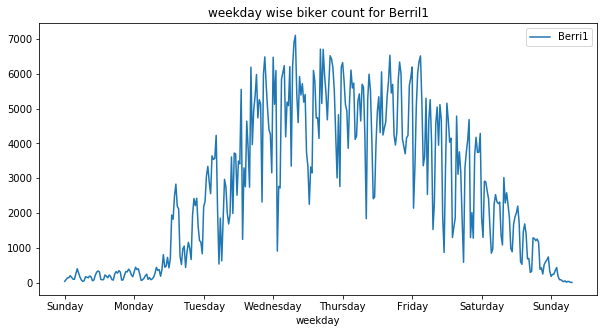

```python
# plot weekday wise biker count for 'Berri1'
df2.plot(x='weekday',y='Berri1',title='weekday wise biker count for Berril1',figsize=(10,5))
```

[figure not shown]